# Flexible Damage Functions

Year 2099 · T<sub>mean</sub> across these regions: 1.96°C

| Region | Raw | Flex | Residual |
| --- | --- | --- | --- |
| MEX.15.720 | 4.19e-5 | 4.19e-5 | 1.09e-8 |
| TUR.7.81 | -3.94e-5 | -3.94e-5 | 3.12e-8 |
| IND.33.528.2113 | 1.84e-4 | 1.84e-4 | -4.52e-8 |
| USA.37.2206 | 2.11e-4 | 2.11e-4 | -4.91e-8 |
| KOR.14.196 | 2.91e-4 | 2.91e-4 | -4.94e-8 |
| CHN.30.315.2167 | -0.00112 | -0.00258 | -0.00147 |
| CHN.30.315.2170 | -0.00109 | -0.00247 | -0.00137 |
| CHN.30.318.2210.Rde47a34c1c843aec | -0.0011 | -0.00246 | -0.00137 |
| CHN.30.318.2205 | -0.00109 | -0.00244 | -0.00136 |
| CHN.30.318.2202 | -0.00108 | -0.00243 | -0.00136 |

**SSP4**

**high**

**Correlation:** 0.9464 | **RMSE:** 0.000147 | **Sign agreement:** 91.0%

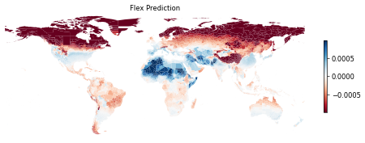

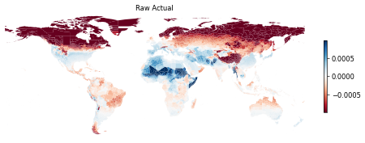

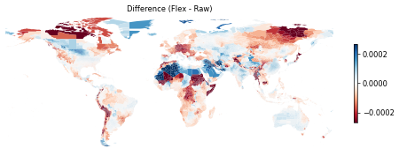

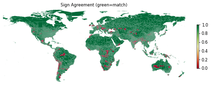

[interactive chart not shown]

Top 5 best predicted Top 5 worst predicted

Year 2099 · T<sub>mean</sub> across these regions: 1.96°C

| Region | Raw | Flex | Residual |
| --- | --- | --- | --- |
| USA.23.1275 | -8.73e-4 | -8.73e-4 | 1.41e-8 |
| USA.36.2126 | 1.43e-4 | 1.43e-4 | -1.82e-8 |
| RUS.36.Rde9c0ffef929e2fe | -0.001 | -0.001 | 2.14e-8 |
| BRA.5.607.1064 | -4.91e-4 | -4.91e-4 | -2.40e-8 |
| BRA.6.660.R352f4b487c0ed565 | -1.91e-4 | -1.91e-4 | 2.49e-8 |
| SOM.7.29 | 0.00274 | 0.00116 | -0.00158 |
| MMR.2.8.46 | 0.00193 | 4.31e-4 | -0.0015 |
| MMR.2.8.45 | 0.00193 | 4.42e-4 | -0.00149 |
| MMR.2.8.43 | 0.00175 | 3.75e-4 | -0.00138 |
| MMR.8.24.123 | 0.00172 | 3.43e-4 | -0.00138 |

**low**

**Correlation:** 0.9577 | **RMSE:** 0.000150 | **Sign agreement:** 90.4%

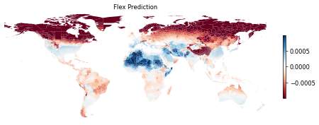

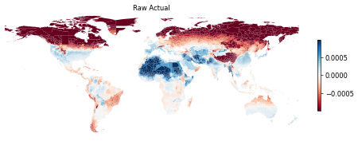

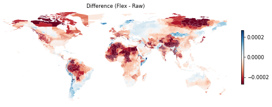

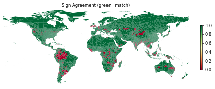

[interactive chart not shown]

Top 5 best predicted Top 5 worst predicted

Year 2099 · T<sub>mean</sub> across these regions: 1.96°C

| Region | Raw | Flex | Residual |
| --- | --- | --- | --- |
| USA.2.90 | -0.00144 | -0.00144 | 3.97e-10 |
| CHN.6.52.315 | 5.74e-5 | 5.74e-5 | -1.12e-8 |
| RUS.71.1950.2067 | -5.14e-4 | -5.14e-4 | -1.49e-8 |
| RUS.71.Rd4141f8ec808f5c1 | -5.14e-4 | -5.14e-4 | -1.49e-8 |
| USA.44.2652 | -1.80e-5 | -1.80e-5 | 5.58e-8 |
| MMR.2.8.46 | 0.002 | 4.31e-4 | -0.00157 |
| MMR.2.8.45 | 0.00201 | 4.42e-4 | -0.00157 |
| MMR.8.24.123 | 0.00182 | 3.43e-4 | -0.00148 |
| MMR.11.42.201 | 0.00181 | 3.47e-4 | -0.00146 |
| MMR.2.8.43 | 0.00183 | 3.75e-4 | -0.00145 |

**SSP5**

**high**

*No data for this scenario.*

**low**

*No data for this scenario.*

**rcp85**

**SSP1**

**high**

*No data for this scenario.*

**low**

*No data for this scenario.*

**SSP2**

**high**

**Correlation:** 0.9157 | **RMSE:** 0.000445 | **Sign agreement:** 92.7%

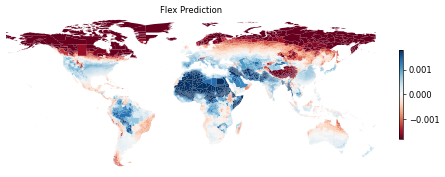

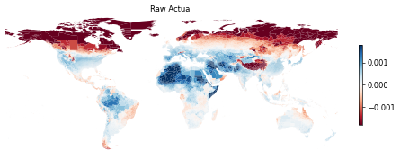

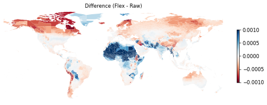

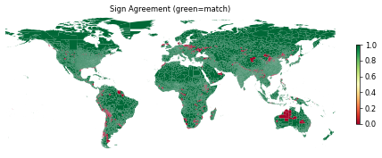

[interactive chart not shown]

Top 5 best predicted Top 5 worst predicted

Year 2099 · T<sub>mean</sub> across these regions: 4.20°C

| Region | Raw | Flex | Residual |
| --- | --- | --- | --- |
| USA.33.1885 | 3.84e-4 | 3.84e-4 | -6.57e-9 |
| VNM.2.16.149.1946 | 2.59e-4 | 2.59e-4 | -1.45e-8 |
| USA.5.202 | 2.78e-4 | 2.78e-4 | 1.97e-8 |
| USA.34.1895 | 4.01e-4 | 4.01e-4 | -3.64e-8 |
| AUS.6.481 | -1.30e-4 | -1.30e-4 | 4.17e-8 |
| SDN.6.16.74.R329752b1f48ceaf7 | 0.00262 | 0.00595 | 0.00333 |
| SDN.6.15.72.223 | 0.00262 | 0.00593 | 0.00331 |
| SDN.6.15.72.222 | 0.00261 | 0.0059 | 0.00329 |
| SDN.6.16.74.227 | 0.00258 | 0.00587 | 0.00329 |
| BFA.29 | 0.00149 | 0.0047 | 0.00321 |

**low**

**Correlation:** 0.9674 | **RMSE:** 0.000304 | **Sign agreement:** 94.7%

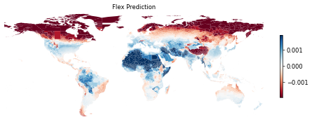

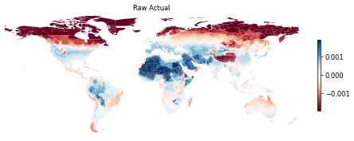

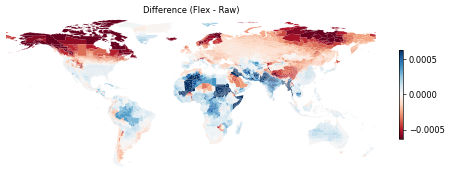

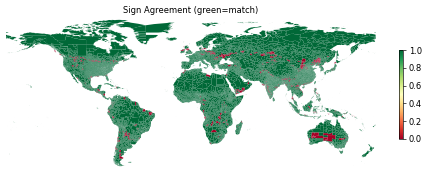

[interactive chart not shown]

Top 5 best predicted Top 5 worst predicted

Year 2099 · T<sub>mean</sub> across these regions: 4.20°C

| Region | Raw | Flex | Residual |
| --- | --- | --- | --- |
| AUS.11.1386 | 2.40e-4 | 2.40e-4 | -1.71e-9 |
| IDN.12.152 | -2.15e-4 | -2.15e-4 | -8.13e-9 |
| AUS.4.145 | -1.70e-4 | -1.70e-4 | 1.33e-8 |
| AUS.4.132 | 2.17e-4 | 2.17e-4 | 1.61e-8 |
| USA.36.2110 | 7.60e-4 | 7.60e-4 | 2.14e-8 |
| SOM.1.R472bf830dca32de3 | 0.00269 | 0.00544 | 0.00275 |
| SOM.7.29 | 0.0022 | 0.00459 | 0.0024 |
| SOM.18.72 | 0.00231 | 0.00469 | 0.00238 |
| MMR.11.42.201 | 9.92e-4 | 0.00308 | 0.00209 |
| MMR.8.24.123 | 9.99e-4 | 0.00307 | 0.00207 |

**SSP3**

**high**

**Correlation:** 0.9498 | **RMSE:** 0.000333 | **Sign agreement:** 92.9%

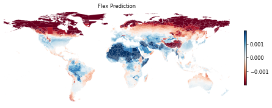

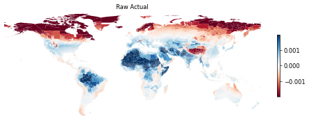

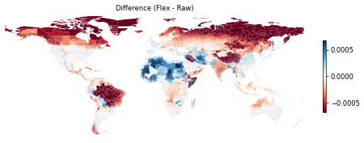

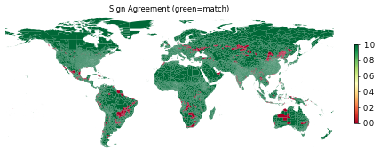

[interactive chart not shown]

Top 5 best predicted Top 5 worst predicted

Year 2099 · T<sub>mean</sub> across these regions: 4.20°C

| Region | Raw | Flex | Residual |
| --- | --- | --- | --- |
| USA.44.2694 | 3.92e-4 | 3.92e-4 | 7.86e-9 |
| CMR.6.33 | 5.27e-5 | 5.27e-5 | -3.42e-8 |
| USA.44.2644 | 6.30e-4 | 6.31e-4 | 3.47e-8 |
| COL.13.481 | 5.79e-4 | 5.79e-4 | -3.91e-8 |
| ZAF.1.71 | -1.25e-4 | -1.25e-4 | 5.05e-8 |
| SOM.7.29 | 0.00688 | 0.0046 | -0.00228 |
| SOM.1.R472bf830dca32de3 | 0.00772 | 0.00544 | -0.00228 |
| CHN.30.318.2202 | -0.00194 | -0.00407 | -0.00213 |
| CHN.30.318.2205 | -0.00186 | -0.00398 | -0.00211 |
| CHN.30.318.2197 | -0.00189 | -0.00399 | -0.0021 |

**low**

**Correlation:** 0.9256 | **RMSE:** 0.000490 | **Sign agreement:** 92.8%

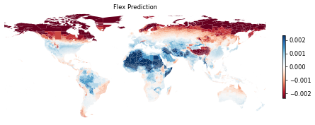

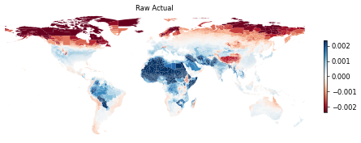

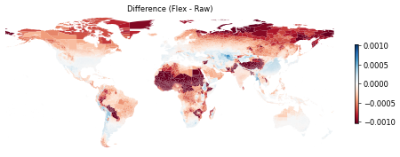

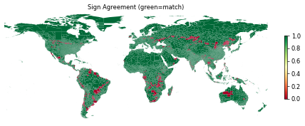

[interactive chart not shown]

Top 5 best predicted Top 5 worst predicted

Year 2099 · T<sub>mean</sub> across these regions: 4.20°C

| Region | Raw | Flex | Residual |
| --- | --- | --- | --- |
| MMR.7.21.106 | 5.83e-4 | 5.83e-4 | 8.48e-9 |
| AUS.4.181 | 6.54e-5 | 6.54e-5 | 1.34e-8 |
| USA.10.384 | 8.22e-5 | 8.22e-5 | -2.24e-8 |
| AUS.10.1141 | 3.67e-4 | 3.67e-4 | -3.44e-8 |
| AUS.7.896 | 2.98e-4 | 2.98e-4 | -4.05e-8 |
| TCD.2.4.16 | 0.00848 | 0.00437 | -0.00411 |
| TCD.1.3 | 0.00752 | 0.00397 | -0.00355 |
| MRT.7.25 | 0.00809 | 0.00456 | -0.00353 |
| BFA.29 | 0.00821 | 0.0047 | -0.00351 |
| TCD.6.19 | 0.00694 | 0.00352 | -0.00341 |

**SSP4**

**high**

**Correlation:** 0.9330 | **RMSE:** 0.000401 | **Sign agreement:** 93.2%

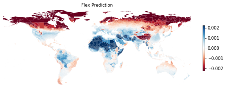

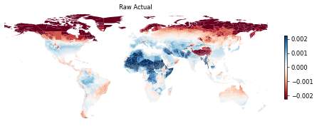

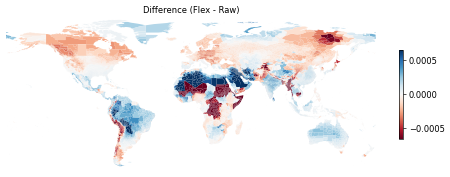

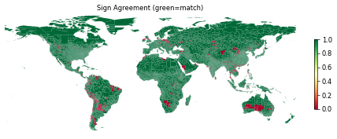

[interactive chart not shown]

Top 5 best predicted Top 5 worst predicted

Year 2099 · T<sub>mean</sub> across these regions: 4.20°C

| Region | Raw | Flex | Residual |
| --- | --- | --- | --- |
| MDG.4.15.72 | 7.38e-4 | 7.38e-4 | 8.99e-9 |
| USA.28.1732 | 9.83e-4 | 9.83e-4 | 1.21e-8 |
| DZA.R9c0b07bee4871793 | 7.14e-4 | 7.14e-4 | -3.22e-8 |
| USA.28.1722 | 9.53e-4 | 9.53e-4 | -6.12e-8 |
| CHN.23.236.1554 | 7.89e-4 | 7.89e-4 | 6.73e-8 |
| SOM.1.R472bf830dca32de3 | 0.0102 | 0.00545 | -0.00475 |
| SOM.7.29 | 0.00906 | 0.0046 | -0.00447 |
| SOM.18.72 | 0.00887 | 0.0047 | -0.00418 |
| MMR.8.24.123 | 0.00723 | 0.00307 | -0.00416 |
| MMR.11.42.201 | 0.00722 | 0.00309 | -0.00414 |

**low**

**Correlation:** 0.9483 | **RMSE:** 0.000547 | **Sign agreement:** 93.7%

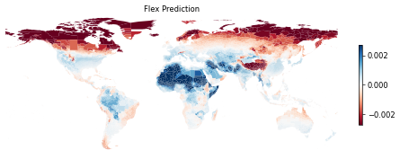

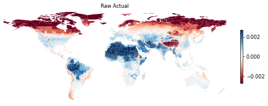

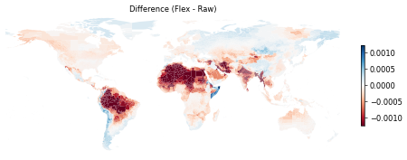

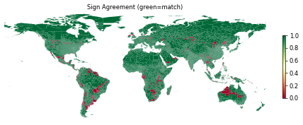

[interactive chart not shown]

Top 5 best predicted Top 5 worst predicted

Year 2099 · T<sub>mean</sub> across these regions: 4.20°C

| Region | Raw | Flex | Residual |
| --- | --- | --- | --- |
| AUS.6.793 | -2.58e-4 | -2.58e-4 | -4.20e-9 |
| BRA.5.392.628 | -7.48e-4 | -7.48e-4 | 5.24e-9 |
| CAN.3.64.1478 | -0.00122 | -0.00122 | -5.63e-9 |
| AUS.4.191 | 4.00e-4 | 4.00e-4 | 1.70e-8 |
| AUS.6.517 | -1.11e-4 | -1.10e-4 | 3.50e-8 |
| IRN.14.135 | 0.00929 | 0.00467 | -0.00462 |
| IRN.14.141 | 0.00925 | 0.00469 | -0.00456 |
| IRN.14.142 | 0.00919 | 0.0047 | -0.00449 |
| IRN.14.148 | 0.00912 | 0.00466 | -0.00446 |
| IRN.14.147 | 0.00882 | 0.00442 | -0.00439 |

**SSP5**

**high**

*No valid predictions.*

**low**

*No valid predictions.*

## 10.1 Scenario Summary

| RCP | SSP | Model | N | Corr | RMSE | Sign% |
| --- | --- | --- | --- | --- | --- | --- |
| rcp45 | SSP1 | high | 24,326 | 0.8921 | 0.000204 | 80.4% |
| rcp45 | SSP1 | low | 24,326 | 0.9441 | 0.000145 | 87.3% |
| rcp45 | SSP2 | high | 24,326 | 0.9377 | 0.000173 | 88.1% |
| rcp45 | SSP2 | low | 24,326 | 0.9766 | 0.000136 | 89.8% |
| rcp45 | SSP3 | high | 24,326 | 0.9393 | 0.000183 | 91.2% |
| rcp45 | SSP3 | low | 24,326 | 0.9189 | 0.000187 | 90.9% |
| rcp45 | SSP4 | high | 24,326 | 0.9464 | 0.000147 | 91.0% |
| rcp45 | SSP4 | low | 24,326 | 0.9577 | 0.00015 | 90.4% |
| rcp85 | SSP2 | high | 24,326 | 0.9157 | 0.000445 | 92.7% |
| rcp85 | SSP2 | low | 24,326 | 0.9674 | 0.000304 | 94.7% |
| rcp85 | SSP3 | high | 24,326 | 0.9498 | 0.000333 | 92.9% |
| rcp85 | SSP3 | low | 24,326 | 0.9256 | 0.00049 | 92.8% |
| rcp85 | SSP4 | high | 24,326 | 0.933 | 0.000401 | 93.2% |
| rcp85 | SSP4 | low | 24,326 | 0.9483 | 0.000547 | 93.7% |

# 11 Data Reference

## 11.1 File Locations

| Item | Path |
| --- | --- |
| Regional CSV | `/project/cil/gcp/flex_damage_funcs/parameters/mortality__allcause__regional_parameters.csv` |
| Global JSON | `/project/cil/gcp/flex_damage_funcs/parameters/mortality__allcause__global_results.json` |
| Metadata JSON | `/project/cil/gcp/flex_damage_funcs/parameters/mortality__allcause__metadata.json` |

## 11.2 Column Definitions

| Column | Description |
| --- | --- |
| `region` | Region identifier (hierarchical code, first 3 chars = country ISO3) |
| `gamma` | Income elasticity quantile value |
| `alpha` | Linear temperature coefficient |
| `beta` | Quadratic temperature coefficient |
| `sigma11` | Var(alpha) |
| `sigma12` | Cov(alpha, beta) |
| `sigma22` | Var(beta) |
| `rho` | Correlation with global residual process |
| `zeta` | Temperature-dependent heteroskedasticity |
| `eta` | Residual standard deviation |
| `rsqr1` | R-squared of polynomial fit |
| `rsqr2` | R-squared of error model |

*Report generated with FlexDamage v1.0.0*